# Model ARMA(2,2)

# Membangkitkan Bangkitkan model ARMA(2,2) dengan 𝜃1 = 0.4, 𝜃2 = 0.6 ,𝜙1 = 0.5 dan 𝜙2 = 0.2 sebanyak 300 data (Manual dan arima.sim)

Model ARMA(2,2) yang digunakan adalah:

$$Y_t = \phi_1Y_{t-1}+\phi_2Y_{t-2}
+Z_t+\theta_1Z_{t-1}+\theta_2Z_{t-2}$$

dengan parameter:

$$\phi_1=0.5,\quad \phi_2=0.2$$

$$\theta_1=0.4,\quad \theta_2=0.6$$

sehingga model yang digunakan adalah:

$$Y_t =
0.5Y_{t-1}
+0.2Y_{t-2}
+Z_t
+0.4Z_{t-1}
+0.6Z_{t-2}$$

dengan:

$$Z_t\sim N(0,1)$$

Sebanyak 300 data dibangkitkan menggunakan metode manual dan fungsi `arima.sim`.

## Manual

```r
# Seed agar hasil dapat direplikasi
set.seed(123)

# Parameter
n <- 300

phi1 <- 0.5
phi2 <- 0.2

theta1 <- 0.4
theta2 <- 0.6

# Burn-in
burn_in <- 100
N <- n + burn_in

# Bangkitkan error
z <- rnorm(N)

# Menyediakan tempat untuk data
y <- numeric(N)

# Nilai awal
y[1] <- z[1]
y[2] <- phi1 * y[1] + z[2] + theta1 * z[1]

# Membentuk model ARMA(2,2)
for (t in 3:N) {

  y[t] <- phi1 * y[t-1] +
    phi2 * y[t-2] +
    z[t] +
    theta1 * z[t-1] +
    theta2 * z[t-2]
}

# Ambil 300 data setelah burn-in
x_manual <- y[(burn_in + 1):N]

# Melihat 10 data pertama
head(x_manual, 10)
```

```
##  [1]  1.20697955  0.56984589 -0.04386348 -0.20005169 -1.34744927 -1.34793569
##  [7] -2.31734440 -3.43717969 -3.70040470 -2.77149745
```

## `(arima.sim)`

```r
set.seed(123)

# Bangkitkan ARMA(2,2)
x_arima <- arima.sim(
  model = list(
    ar = c(0.5, 0.2),
    ma = c(0.4, 0.6)
  ),
  n = 300
)

# Melihat 10 data pertama
head(x_arima, 10)
```

```
## Time Series:
## Start = 1
## End = 10
## Frequency = 1
##  [1] -3.11187150 -2.78699743 -1.12528900 -0.87493596 -0.03472262  0.84062710
##  [7]  1.47250989  2.61429024  3.14579988  3.41808039
```

# Membuat Plot Time Series, ACF, PACF dan EACF

## Plot time series

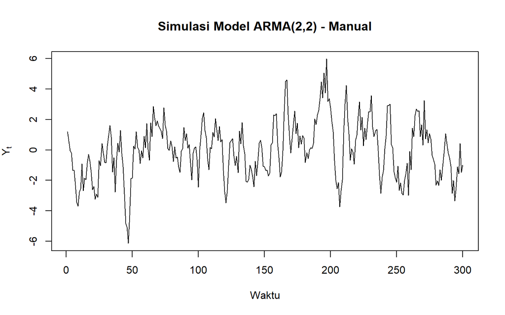

```r
plot(
  ts(x_manual),
  main = "Simulasi Model ARMA(2,2) - Manual",
  ylab = expression(Y[t]),
  xlab = "Waktu"
)
```

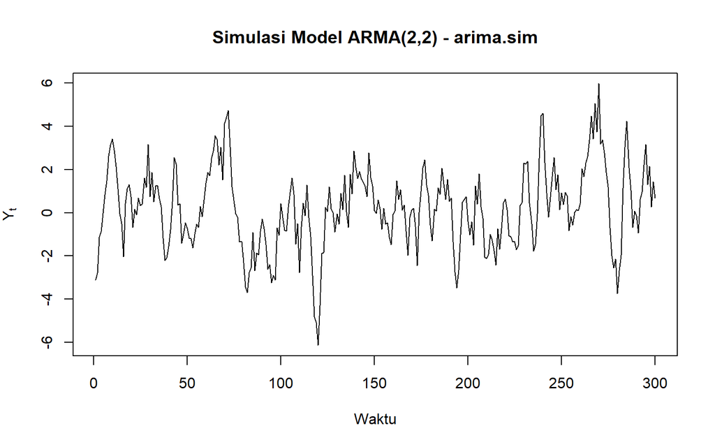

```r
plot(
  ts(x_arima),
  main = "Simulasi Model ARMA(2,2) - arima.sim",
  ylab = expression(Y[t]),
  xlab = "Waktu"
)
```

Berdasarkan plot time series, data berfluktuasi di sekitar nilai rata-rata yang relatif konstan dan tidak menunjukkan adanya tren naik atau turun secara sistematis. Penyebaran data juga relatif stabil sepanjang waktu sehingga secara visual data dapat dianggap stasioner.

## Plot ACF

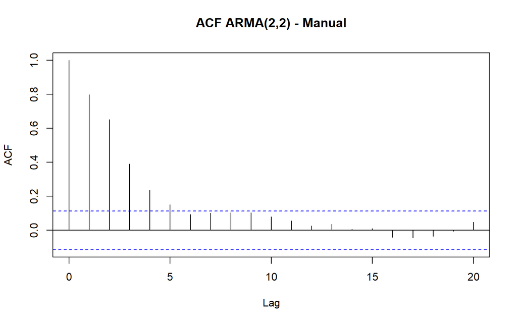

```r
acf(
  x_manual,
  lag.max = 20,
  main = "ACF ARMA(2,2) - Manual"
)
```

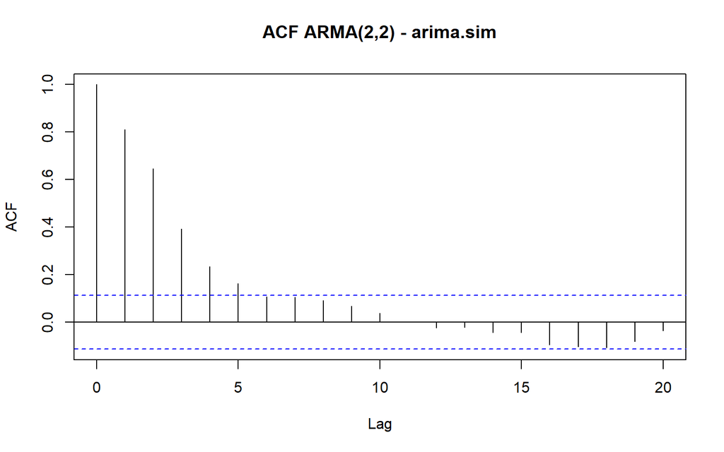

```r
acf(
  x_arima,
  lag.max = 20,
  main = "ACF ARMA(2,2) - arima.sim"
)
```

Pada model ARMA(2,2), ACF umumnya meluruh secara bertahap (tailing off). Hal ini terjadi karena terdapat komponen AR yang menyebabkan korelasi pada beberapa lag tidak langsung terputus setelah lag tertentu.

## Plot PACF

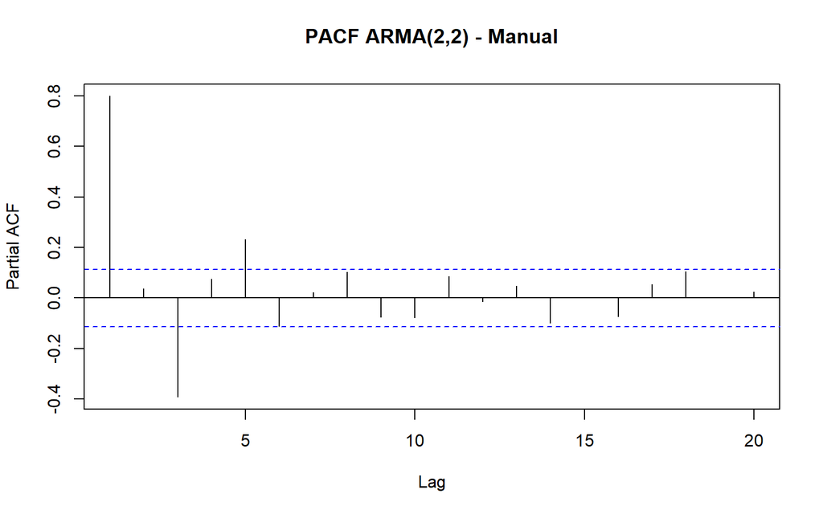

```r
pacf(
  x_manual,
  lag.max = 20,
  main = "PACF ARMA(2,2) - Manual"
)
```

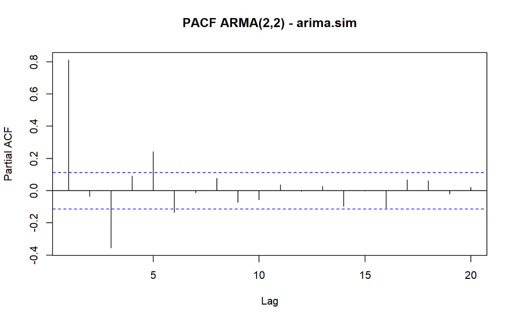

```r
pacf(
  x_arima,
  lag.max = 20,
  main = "PACF ARMA(2,2) - arima.sim"
)
```

Pada model ARMA(2,2), PACF juga tidak menunjukkan pola cut-off yang sejelas model AR murni. Baik ACF maupun PACF cenderung meluruh secara bertahap sehingga diperlukan alat tambahan seperti EACF untuk membantu mengidentifikasi orde AR dan MA.

## Plot EACF

```r
# Memanggil package TSA
library(TSA)
```

```r
eacf(x_manual)
```

```
## AR/MA
##   0 1 2 3 4 5 6 7 8 9 10 11 12 13
## 0 x x x x x o o o o o o  o  o  o
## 1 o x o o o x o o o o o  o  o  o
## 2 o x x o o x o o o o o  o  o  o
## 3 x x o o o x o o o o o  o  o  o
## 4 x x o o o x o o o o o  o  o  o
## 5 x o x x x x o o o o o  o  o  o
## 6 x o x x x o o o o o o  o  o  o
## 7 x x o o x o o o o o o  o  o  o
```

```r
eacf(x_arima)
```

```
## AR/MA
##   0 1 2 3 4 5 6 7 8 9 10 11 12 13
## 0 x x x x x o o o o o o  o  o  o
## 1 o x o o o x o o o o o  o  o  o
## 2 o x o o o x o o o o o  o  o  o
## 3 x x o x o x o o o o o  o  o  o
## 4 x x o x o x o o o o o  o  o  o
## 5 x x o x x o o o o o o  o  o  o
## 6 x x o x x o o o o o o  o  o  o
## 7 x x x x x o o o o o o  o  o  o
```

EACF digunakan untuk membantu menentukan orde model ARMA. Pola segitiga yang terbentuk dari simbol o dan x digunakan sebagai dasar identifikasi orde AR dan MA. Karena data dibangkitkan dari model ARMA(2,2), EACF diharapkan memberikan indikasi orde AR sekitar 2 dan orde MA sekitar 2.

# Membuat scatterplot antara 𝑌𝑡 dengan 𝑌𝑡−1, 𝑌𝑡 dengan 𝑌𝑡−2 serta 𝑌𝑡dengan 𝑌𝑡−3

## Scatterplot antara 𝑌𝑡 dengan 𝑌𝑡−1

### Manual

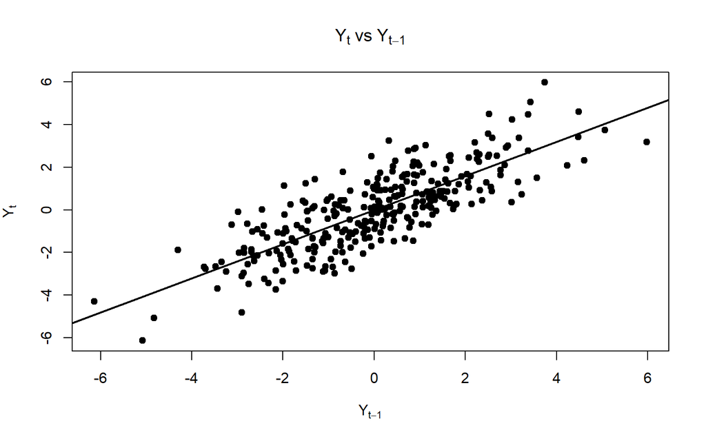

```r
plot(
  x_manual[1:(length(x_manual)-1)],
  x_manual[2:length(x_manual)],
  main = expression(Y[t] ~ "vs" ~ Y[t-1]),
  xlab = expression(Y[t-1]),
  ylab = expression(Y[t]),
  pch = 19
)

abline(
  lm(
    x_manual[2:length(x_manual)] ~
      x_manual[1:(length(x_manual)-1)]
  ),
  lwd = 2
)
```

### `(arima.sim)`

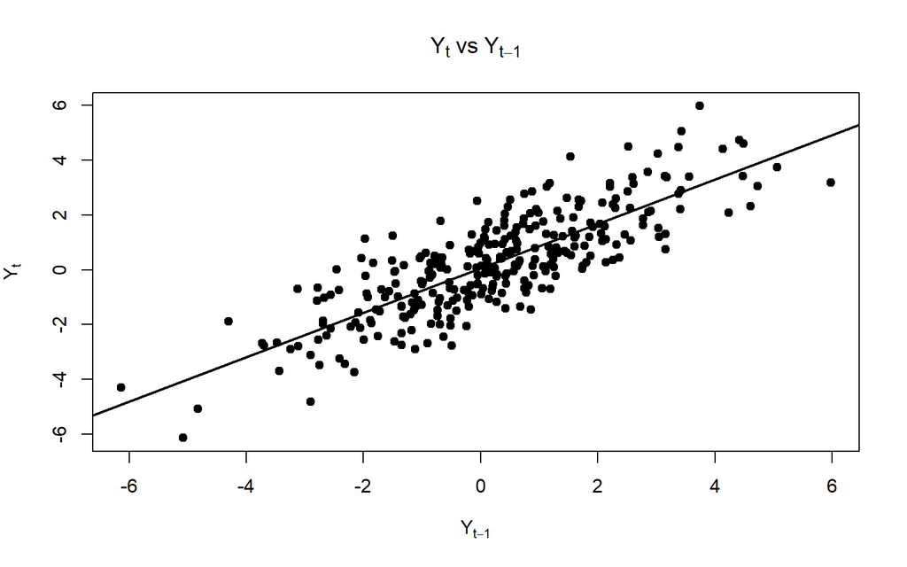

```r
plot(
  x_arima[1:(length(x_arima)-1)],
  x_arima[2:length(x_arima)],
  main = expression(Y[t] ~ "vs" ~ Y[t-1]),
  xlab = expression(Y[t-1]),
  ylab = expression(Y[t]),
  pch = 19
)

abline(
  lm(
    x_arima[2:length(x_arima)] ~
      x_arima[1:(length(x_arima)-1)]
  ),
  lwd = 2
)
```

## Scatterplot antara 𝑌𝑡 dengan 𝑌𝑡−2

### Manual

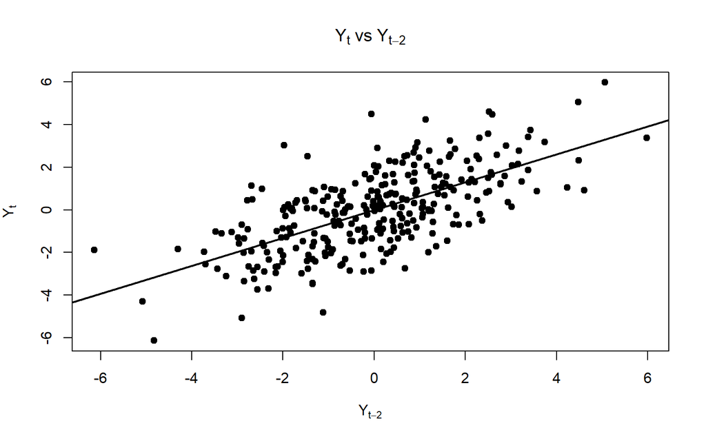

```r
plot(
  x_manual[1:(length(x_manual)-2)],
  x_manual[3:length(x_manual)],
  main = expression(Y[t] ~ "vs" ~ Y[t-2]),
  xlab = expression(Y[t-2]),
  ylab = expression(Y[t]),
  pch = 19
)

abline(
  lm(
    x_manual[3:length(x_manual)] ~
      x_manual[1:(length(x_manual)-2)]
  ),
  lwd = 2
)
```

### `(arima.sim)`

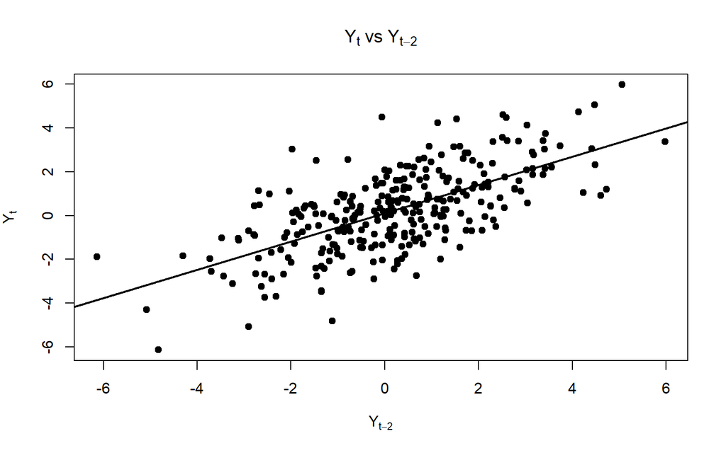

```r
plot(
  x_arima[1:(length(x_arima)-2)],
  x_arima[3:length(x_arima)],
  main = expression(Y[t] ~ "vs" ~ Y[t-2]),
  xlab = expression(Y[t-2]),
  ylab = expression(Y[t]),
  pch = 19
)

abline(
  lm(
    x_arima[3:length(x_arima)] ~
      x_arima[1:(length(x_arima)-2)]
  ),
  lwd = 2
)
```

## Scatterplot antara 𝑌𝑡 dengan 𝑌𝑡−3

### Manual

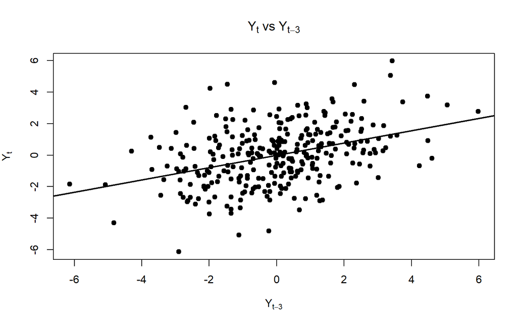

```r
plot(
  x_manual[1:(length(x_manual)-3)],
  x_manual[4:length(x_manual)],
  main = expression(Y[t] ~ "vs" ~ Y[t-3]),
  xlab = expression(Y[t-3]),
  ylab = expression(Y[t]),
  pch = 19
)

abline(
  lm(
    x_manual[4:length(x_manual)] ~
      x_manual[1:(length(x_manual)-3)]
  ),
  lwd = 2
)
```

### `(arima.sim)`

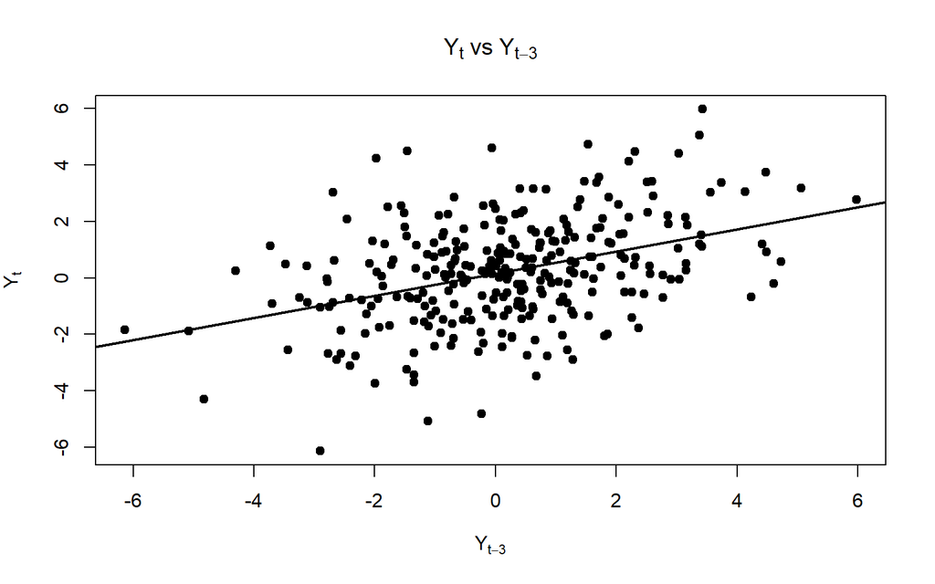

```r
plot(
  x_arima[1:(length(x_arima)-3)],
  x_arima[4:length(x_arima)],
  main = expression(Y[t] ~ "vs" ~ Y[t-3]),
  xlab = expression(Y[t-3]),
  ylab = expression(Y[t]),
  pch = 19
)

abline(
  lm(
    x_arima[4:length(x_arima)] ~
      x_arima[1:(length(x_arima)-3)]
  ),
  lwd = 2
)
```

# Mengitung autokorelasi masing masing baik dari data bangkitan maupun secara teoritis

## Autokorelasi dari data bangkitan

### Manual

```r
acf_manual <- acf(
  x_manual,
  lag.max = 10,
  plot = FALSE
)

acf_manual$acf
```

```
## , , 1
##
##             [,1]
##  [1,] 0.79888663
##  [2,] 0.65191604
##  [3,] 0.38995421
##  [4,] 0.23636939
##  [5,] 0.15105214
##  [6,] 0.09395998
##  [7,] 0.10068434
##  [8,] 0.10357721
##  [9,] 0.10257870
## [10,] 0.07953245
```

### `(arima.sim)`

```r
acf_arima <- acf(
  x_arima,
  lag.max = 10,
  plot = FALSE
)

acf_arima$acf
```

```
## , , 1
##
##             [,1]
##  [1,] 0.81078914
##  [2,] 0.64540289
##  [3,] 0.39166833
##  [4,] 0.23298922
##  [5,] 0.16167096
##  [6,] 0.10753738
##  [7,] 0.10613054
##  [8,] 0.09157156
##  [9,] 0.06809308
## [10,] 0.03690698
```

## Autokorelasi teoritis ARMA(2,2)

```r
# Parameter
phi1 <- 0.5
phi2 <- 0.2

theta1 <- 0.4
theta2 <- 0.6

# Banyak lag
lag_max <- 10

# Menyediakan tempat ACF teoritis
acf_theoretical <- numeric(lag_max + 1)

# rho(0)
acf_theoretical[1] <- 1

# rho(1)
acf_theoretical[2] <- 0.8591993

# rho(2)
acf_theoretical[3] <- 0.7491908

# rho(k), k >= 3
for (k in 3:lag_max) {

  acf_theoretical[k + 1] <-
    phi1 * acf_theoretical[k] +
    phi2 * acf_theoretical[k - 1]
}

acf_theoretical
```

```
##  [1] 1.00000000 0.85919930 0.74919080 0.54643526 0.42305579 0.32081495
##  [7] 0.24501863 0.18667231 0.14233988 0.10850440 0.08272018
```

## Gabungan data bangkitan dan teoritis

### Manual

```r
# ACF data bangkitan
acf_sample <- acf(
  x_manual,
  lag.max = 10,
  plot = FALSE
)

# Tabel perbandingan
acf_comparison <- data.frame(
  Lag = 1:10,
  ACF_Bangkitan = as.numeric(acf_sample$acf)[2:11],
  ACF_Teoritis = acf_theoretical[2:11]
)

acf_comparison
```

```
##    Lag ACF_Bangkitan ACF_Teoritis
## 1    1    0.65191604   0.85919930
## 2    2    0.38995421   0.74919080
## 3    3    0.23636939   0.54643526
## 4    4    0.15105214   0.42305579
## 5    5    0.09395998   0.32081495
## 6    6    0.10068434   0.24501863
## 7    7    0.10357721   0.18667231
## 8    8    0.10257870   0.14233988
## 9    9    0.07953245   0.10850440
## 10  10            NA   0.08272018
```

### `(arima,sim)`

```r
# ACF data bangkitan
acf_sample_sim <- acf(
  x_arima,
  lag.max = 10,
  plot = FALSE
)

# Tabel perbandingan
acf_comparison_sim <- data.frame(
  Lag = 1:10,
  ACF_Bangkitan = as.numeric(acf_sample_sim$acf)[2:11],
  ACF_Teoritis = acf_theoretical[2:11]
)

acf_comparison_sim
```

```
##    Lag ACF_Bangkitan ACF_Teoritis
## 1    1    0.64540289   0.85919930
## 2    2    0.39166833   0.74919080
## 3    3    0.23298922   0.54643526
## 4    4    0.16167096   0.42305579
## 5    5    0.10753738   0.32081495
## 6    6    0.10613054   0.24501863
## 7    7    0.09157156   0.18667231
## 8    8    0.06809308   0.14233988
## 9    9    0.03690698   0.10850440
## 10  10            NA   0.08272018
```